# POLS 2072Q

Lecture 4 | Observations and Variables

## Plan for Today

- Average or mean of a variable
  - How to compute it?
  - How to interpret it?

## Average or Mean of a Variable: How to Compute it

- Sum the values across all observations and divide the result by the total number of observations
- \(\bar{X}\) (pronounced X-bar) stands for the average of X
- \(\sum_{i=1}^{n}X_i\) stands for the sum of all \(X_i\) (observations of X) from i = 1 to i = n
  - This means from the first observation of the variable X to the last one (\(\sum\) is the Greek letter sigma)
- \(X_i\) stands for a particular observation of X, where i denotes the position of the observation and n is the total number of observations in the variable
- Example: if X = {10, 4, 6, 8, 22}, then:
  - n = ?
  - \(\bar{X}\) = ?
- Let’s compute it!

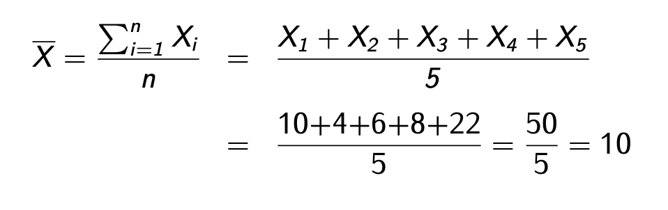

## Average or Mean of a Variable: How to Interpret it?

- First, we need to figure out the quantity in which the value is measured
  - Whenever interpreting numeric results, you should make it clear whether the number is measured in points, percents, miles, kilometers, etc.
  - This is called the unit of measurement

## Unit of Measurement of the Mean of a Variable

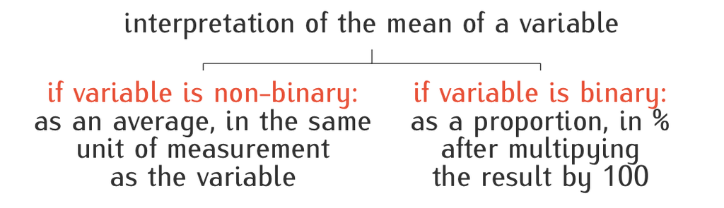

- When the variable is non-binary , the mean should be interpreted as an average in the same unit of measurement as the values in the variable
- When the variable is binary, the mean should be interpreted as a proportion, in % after multiplying the result by 100
  - Why?
    - Because the mean of a binary variable is equivalent to the proportion of the observations that have the characteristic identified by the variable (i.e., that meet a criterion)
  - The proportion of observations in a variable that meet a criterion is calculated as:
    - \(\frac{number \ of \ observations \ that \ meet \ criterion}{total \ number \ of \ observations}\)

## Why do We Analyze Data?

- MEASURE: to infer population characteristics from samples
  - What proportion of constituents support a particular policy?
- PREDICT: to make predictions
  - Who is the most likely candidate to win an upcoming election?
- EXPLAIN: to estimate the causal effect of a treatment on an outcome
  - What is the effect of small classrooms on student performance?
- Throughout the semester we will continually progress from simple to more complex methods

## For Next Class

- Review what you learned today
- Do new set of readings:
  - R4DS Chapter 4
  - R4DS Chapter 6
  - R4DS Chapter 7
  - R4DS Chapter 11
  - R4DS Chapter 12.5
  - HOPR Appendix D
    - Follow along the exercises with your own computer
- Bring your laptops to class